# 078373_Stats2_Report

Michelle Paterson

29/03/2022

# Naval Communications Analysis

## Network Analysis

The navy communications data contains 2 tables. The first is a record of communications between naval vessels. There is a source and recipient of the communication as well as the type of communication (morse or radio) and the duration. There are 193 entries in the table. Duration of communication ranges from 0 to 8.5 minutes and 84 communications were by morse and 109 by radio. The second table lists each naval resource and what type of vessel it is. This shows that there are 20 different vessels included and there are 7 different types: aircraft carrier (5); battlecruiser (1); battleship (4); cruiser (4); escort carrier (2); repair ship (2); and submarine (2).

```
## IGRAPH fecba57 DN-B 20 193 --
## + attr: name (v/c), type (v/c), Type (e/c), duration (e/n)
## + edges from fecba57 (vertex names):
##  [1] HMS Eagle    ->HMS Ark Royal       HMS Eagle    ->HMS Unicorn
##  [3] HMS Eagle    ->HMS Activity        HMS Eagle    ->HMS Pegasus
##  [5] HMS Ark Royal->HMS Eagle           HMS Ark Royal->HMS Audacity
##  [7] HMS Ark Royal->HMS Thames          HMS Ark Royal->HMS Royal Sovereign
##  [9] HMS Ark Royal->HMS Royal Oak       HMS Ark Royal->HMS Nelson
## [11] HMS Ark Royal->HMS Warspite        HMS Hermes   ->HMS Ark Royal
## [13] HMS Hermes   ->HMS Hood            HMS Hermes   ->HMS Upholder
## [15] HMS Hermes   ->HMS Thames          HMS Hermes   ->HMS Royal Sovereign
## + ... omitted several edges
```

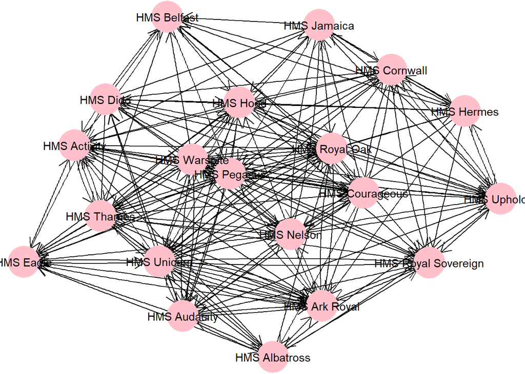

There are 20 vertices and 193 edges.

```
## + 20/20 vertices, named, from fecba57:
##  [1] HMS Activity        HMS Albatross       HMS Ark Royal
##  [4] HMS Audacity        HMS Belfast         HMS Cornwall
##  [7] HMS Courageous      HMS Dido            HMS Eagle
## [10] HMS Hermes          HMS Hood            HMS Jamaica
## [13] HMS Nelson          HMS Pegasus         HMS Royal Oak
## [16] HMS Royal Sovereign HMS Thames          HMS Unicorn
## [19] HMS Upholder        HMS Warspite
```

```
## + 193/193 edges from fecba57 (vertex names):
##  [1] HMS Eagle    ->HMS Ark Royal       HMS Eagle    ->HMS Unicorn
##  [3] HMS Eagle    ->HMS Activity        HMS Eagle    ->HMS Pegasus
##  [5] HMS Ark Royal->HMS Eagle           HMS Ark Royal->HMS Audacity
##  [7] HMS Ark Royal->HMS Thames          HMS Ark Royal->HMS Royal Sovereign
##  [9] HMS Ark Royal->HMS Royal Oak       HMS Ark Royal->HMS Nelson
## [11] HMS Ark Royal->HMS Warspite        HMS Hermes   ->HMS Ark Royal
## [13] HMS Hermes   ->HMS Hood            HMS Hermes   ->HMS Upholder
## [15] HMS Hermes   ->HMS Thames          HMS Hermes   ->HMS Royal Sovereign
## [17] HMS Hermes   ->HMS Nelson          HMS Hermes   ->HMS Dido
## [19] HMS Hermes   ->HMS Cornwall        HMS Hermes   ->HMS Belfast
## + ... omitted several edges
```

This is the number of unique other vessels that any particular vessel is communicating with, including outgoing, incoming and total communications. HMS Ark Royal has the most incoming communications with 17 while HMS Albatross has the least with only 5. HMS Unicorn made 19 outgoing communications; this was the most while HMS Eagle made the least with 4.

```
##       HMS Albatross          HMS Hermes         HMS Jamaica            HMS Dido
##                   5                   5                   5                   6
##         HMS Belfast        HMS Warspite        HMS Cornwall          HMS Thames
##                   7                   7                   9                   9
##        HMS Audacity      HMS Courageous         HMS Unicorn        HMS Activity
##                  10                  10                  10                  11
##           HMS Eagle          HMS Nelson HMS Royal Sovereign        HMS Upholder
##                  11                  11                  11                  11
##            HMS Hood         HMS Pegasus       HMS Royal Oak       HMS Ark Royal
##                  12                  13                  13                  17
```

```
##           HMS Eagle HMS Royal Sovereign         HMS Belfast       HMS Ark Royal
##                   4                   5                   6                   7
##        HMS Activity       HMS Albatross        HMS Audacity        HMS Cornwall
##                   8                   8                   8                   8
##         HMS Pegasus            HMS Dido          HMS Hermes            HMS Hood
##                   8                   9                   9                   9
##         HMS Jamaica        HMS Upholder      HMS Courageous          HMS Nelson
##                   9                   9                  10                  11
##       HMS Royal Oak          HMS Thames        HMS Warspite         HMS Unicorn
##                  13                  15                  18                  19
```

```
##       HMS Albatross         HMS Belfast          HMS Hermes         HMS Jamaica
##                  13                  13                  14                  14
##            HMS Dido           HMS Eagle HMS Royal Sovereign        HMS Cornwall
##                  15                  15                  16                  17
##        HMS Audacity        HMS Activity      HMS Courageous        HMS Upholder
##                  18                  19                  20                  20
##            HMS Hood         HMS Pegasus          HMS Nelson       HMS Ark Royal
##                  21                  21                  22                  24
##          HMS Thames        HMS Warspite       HMS Royal Oak         HMS Unicorn
##                  24                  25                  26                  29
```

When looking at the strength measurement it can be seen that HMS Unicorn had the strongest network with the highest number of communications (29) while HMS ALbatross had the least communications (13).

```
##       HMS Albatross         HMS Belfast          HMS Hermes         HMS Jamaica
##                  13                  13                  14                  14
##            HMS Dido           HMS Eagle HMS Royal Sovereign        HMS Cornwall
##                  15                  15                  16                  17
##        HMS Audacity        HMS Activity      HMS Courageous        HMS Upholder
##                  18                  19                  20                  20
##            HMS Hood         HMS Pegasus          HMS Nelson       HMS Ark Royal
##                  21                  21                  22                  24
##          HMS Thames        HMS Warspite       HMS Royal Oak         HMS Unicorn
##                  24                  25                  26                  29
```

```
##           HMS Eagle HMS Royal Sovereign         HMS Belfast            HMS Hood
##           0.5000000           0.5428571           0.5937500           0.5937500
##       HMS Ark Royal        HMS Activity       HMS Albatross        HMS Audacity
##           0.6129032           0.6333333           0.6333333           0.6333333
##        HMS Cornwall         HMS Pegasus            HMS Dido          HMS Hermes
##           0.6333333           0.6333333           0.6551724           0.6551724
##         HMS Jamaica        HMS Upholder      HMS Courageous          HMS Thames
##           0.6551724           0.6551724           0.6785714           0.6785714
##          HMS Nelson         HMS Unicorn       HMS Royal Oak        HMS Warspite
##           0.7037037           0.7037037           0.7600000           0.7600000
```

```
## Using `stress` as default layout
```

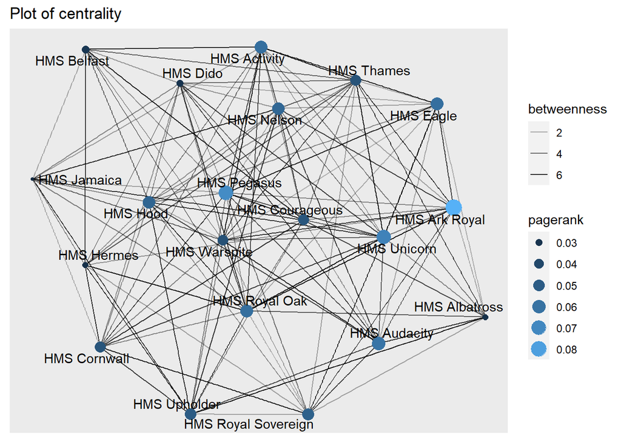

This network has just one component; it is made up of just one group of nodes.

```
## $membership
##        HMS Activity       HMS Albatross       HMS Ark Royal        HMS Audacity
##                   1                   1                   1                   1
##         HMS Belfast        HMS Cornwall      HMS Courageous            HMS Dido
##                   1                   1                   1                   1
##           HMS Eagle          HMS Hermes            HMS Hood         HMS Jamaica
##                   1                   1                   1                   1
##          HMS Nelson         HMS Pegasus       HMS Royal Oak HMS Royal Sovereign
##                   1                   1                   1                   1
##          HMS Thames         HMS Unicorn        HMS Upholder        HMS Warspite
##                   1                   1                   1                   1
##
## $csize
## [1] 20
##
## $no
## [1] 1
```

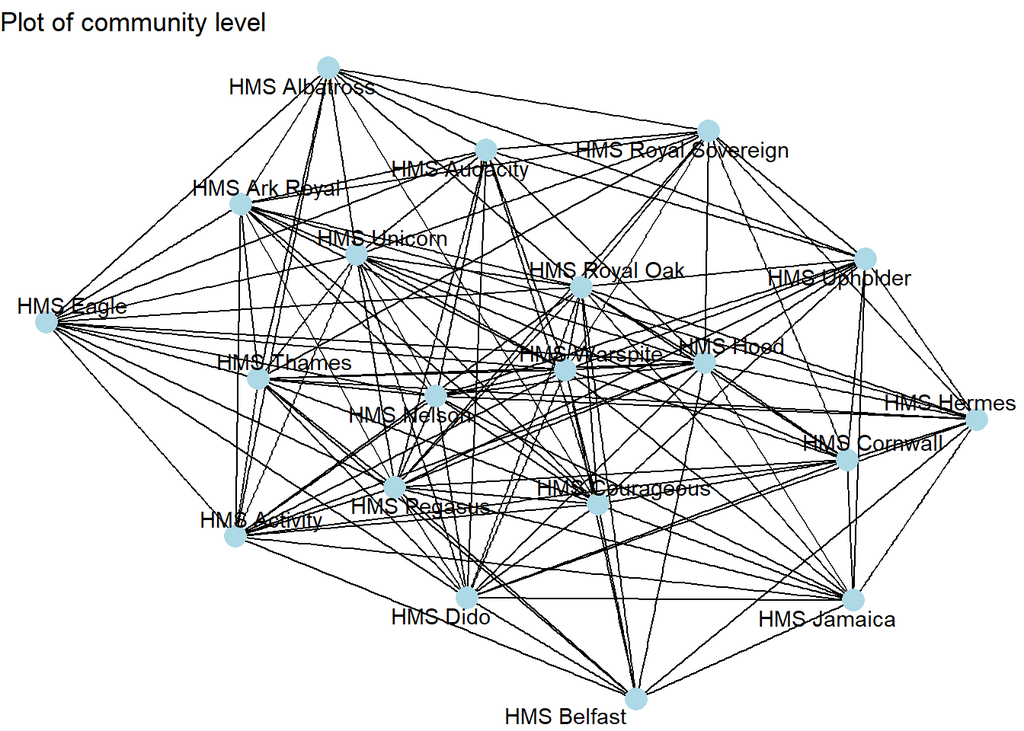

Using walktrap to detect clusters shows 2 clusters with a modularity score of 0.091. Changing the number of steps in the walk did not result in any better score than this.

```
## $membership
##        HMS Activity       HMS Albatross       HMS Ark Royal        HMS Audacity
##                   1                   1                   1                   1
##         HMS Belfast        HMS Cornwall      HMS Courageous            HMS Dido
##                   1                   1                   1                   1
##           HMS Eagle          HMS Hermes            HMS Hood         HMS Jamaica
##                   1                   1                   1                   1
##          HMS Nelson         HMS Pegasus       HMS Royal Oak HMS Royal Sovereign
##                   1                   1                   1                   1
##          HMS Thames         HMS Unicorn        HMS Upholder        HMS Warspite
##                   1                   1                   1                   1
##
## $csize
## [1] 20
##
## $no
## [1] 1
```

```
## IGRAPH clustering walktrap, groups: 2, mod: 0.091
## + groups:
##   $`1`
##    [1] "HMS Activity"   "HMS Belfast"    "HMS Cornwall"   "HMS Courageous"
##    [5] "HMS Dido"       "HMS Hermes"     "HMS Hood"       "HMS Jamaica"
##    [9] "HMS Nelson"     "HMS Pegasus"    "HMS Upholder"   "HMS Warspite"
##
##   $`2`
##   [1] "HMS Albatross"       "HMS Ark Royal"       "HMS Audacity"
##   [4] "HMS Eagle"           "HMS Royal Oak"       "HMS Royal Sovereign"
##   [7] "HMS Thames"          "HMS Unicorn"
##
```

### Network Level

The longest path between 2 nodes is 3 edges and can be seen below: HMS Eagle > HMS Activity > HMS Belfast > HMS Hermes. The mean distance shows that the average number of edges between any two nodes in the network is 1.563 and the first five can be seen below as an example.

```
## [1] 3
```

```
## + 4/20 vertices, named, from fecba57:
## [1] HMS Eagle    HMS Activity HMS Belfast  HMS Hermes
```

```
## [1] 1.563158
```

```
##               HMS Activity HMS Albatross HMS Ark Royal HMS Audacity HMS Belfast
## HMS Activity             0             1             1            2           1
## HMS Albatross            1             0             1            1           2
## HMS Ark Royal            1             1             0            1           2
## HMS Audacity             2             1             1            0           2
## HMS Belfast              1             2             2            2           0
```

## Sentiment Analysis

Three books were used for the sentiment analysis with the common theme of the British Navy. These were The British Navy Book by Cyril Field, The British Navy in Battle by Arthur Joseph Hungerford Pollen and Flag and Fleet: How the British Navy Won the Freedom of the Seas by William Wood. The books were read in and any unnecessary introductory lines were removed. The texts were then collated in a corpus and any stop words removed. This allowed them to analysed.

### Word Count and Frequency

```
## # A tibble: 3 x 2
##   source     n
##   <chr>  <int>
## 1 Battle 40616
## 2 Flag   32834
## 3 Navy   41901
```

```
## # A tibble: 7,182 x 2
##    word         n
##    <chr>    <int>
##  1 fleet      380
##  2 battle     351
##  3 german     350
##  4 action     335
##  5 ships      328
##  6 enemy      324
##  7 sea        291
##  8 british    288
##  9 war        284
## 10 cruisers   263
## # ... with 7,172 more rows
```

```
## # A tibble: 9,901 x 2
##    word       n
##    <chr>  <int>
##  1 ships    416
##  2 ship     366
##  3 guns     330
##  4 time     250
##  5 war      202
##  6 fire     186
##  7 naval    184
##  8 sea      175
##  9 gun      166
## 10 german   164
## # ... with 9,891 more rows
```

```
## # A tibble: 6,803 x 2
##    word        n
##    <chr>   <int>
##  1 british   502
##  2 sea       441
##  3 war       311
##  4 fleet     271
##  5 french    221
##  6 navy      198
##  7 german    181
##  8 ships     171
##  9 germans   156
## 10 english   154
## # ... with 6,793 more rows
```

Due to the high word count in the corpus it was decided to choose words that appear more than 250 times in the word count. The highest frequency words are what would be expected given the topic of the books: British; ships; sea; war; and fleet.

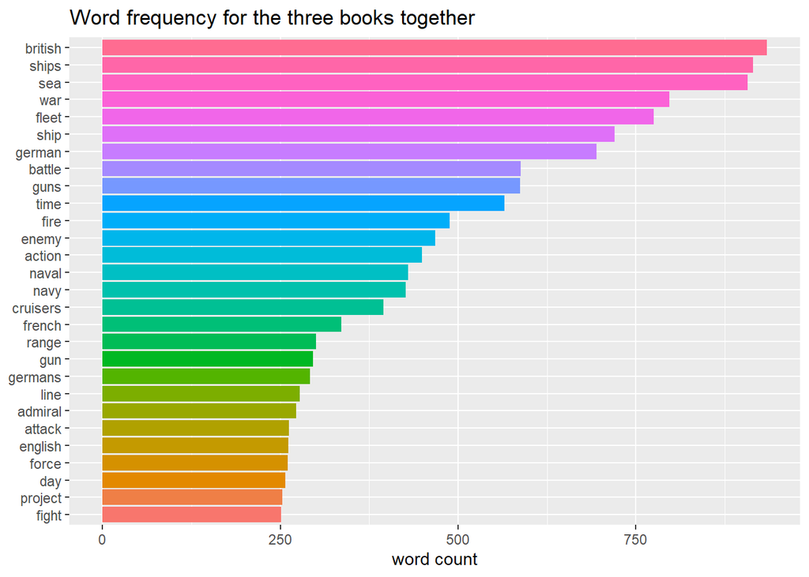

[interactive chart not shown]

When analysed as individual texts the results of the word counts showed many similarities. The same words as previously feature highly along with other common words such as battle, German and gun/s. As this was analysis of individual texts it was decided to feature words that occurred more than 100 times in a text.

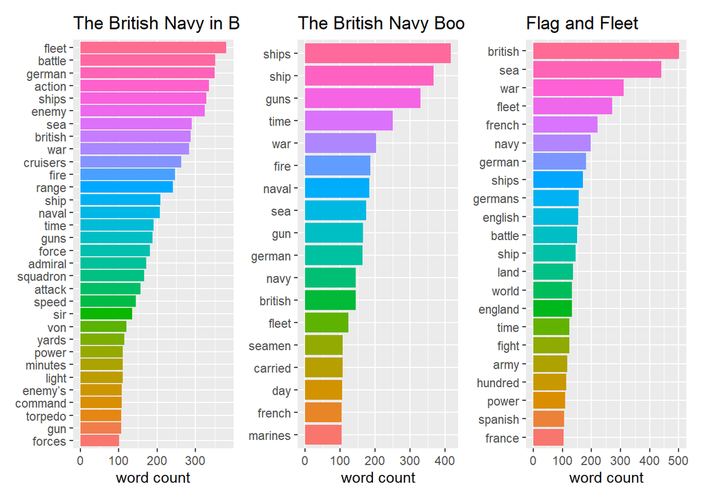

### Word importance weighting

```
## # A tibble: 23,886 x 6
## # Groups:   source [3]
##    source word              n       tf   idf  tf_idf
##    <chr>  <chr>         <int>    <dbl> <dbl>   <dbl>
##  1 Battle enemy’s         108 0.00266  1.10  0.00292
##  2 Battle _koenigsberg_    57 0.00140  1.10  0.00154
##  3 Navy   breech           49 0.00117  1.10  0.00128
##  4 Battle o’clock          47 0.00116  1.10  0.00127
##  5 Battle beatty’s         44 0.00108  1.10  0.00119
##  6 Flag   spaniards        96 0.00292  0.405 0.00119
##  7 Flag   drake            89 0.00271  0.405 0.00110
##  8 Flag   spain            86 0.00262  0.405 0.00106
##  9 Flag   celts            30 0.000914 1.10  0.00100
## 10 Flag   norsemen         30 0.000914 1.10  0.00100
## # ... with 23,876 more rows
```

When analysed for word importance it is seen that “enemy’s” has by far the highest importance rating followed by “Koenigsberg” with these being the two most important words for The British Navy in Battle. “Breech” was the most important word for The British Navy Book while or Flag and Fleet it was “Spaniards”.

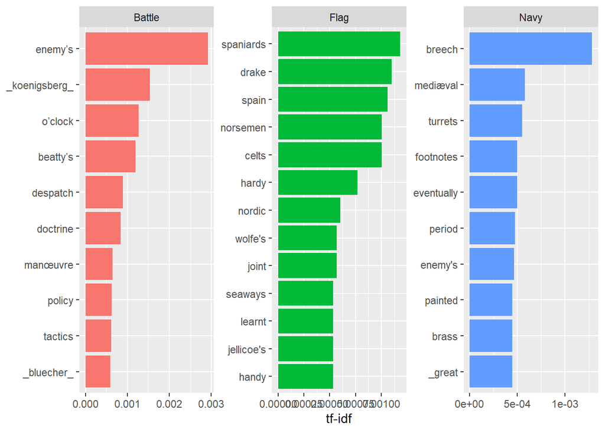

### Word networks

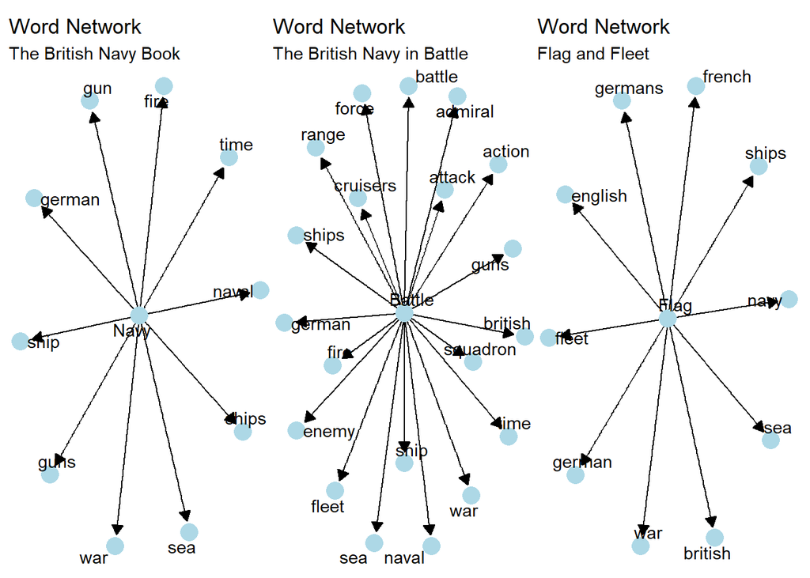

### Positivity measures

It can be seen that when the text is allocated a positive or negative leaning, the corpus contains considerably more negative words than positive.

```
## # A tibble: 6 x 3
##   word    sentiment     n
##   <chr>   <chr>     <int>
## 1 enemy   negative    468
## 2 attack  negative    262
## 3 victory positive    140
## 4 grand   positive    126
## 5 lost    negative    107
## 6 fast    positive    101
```

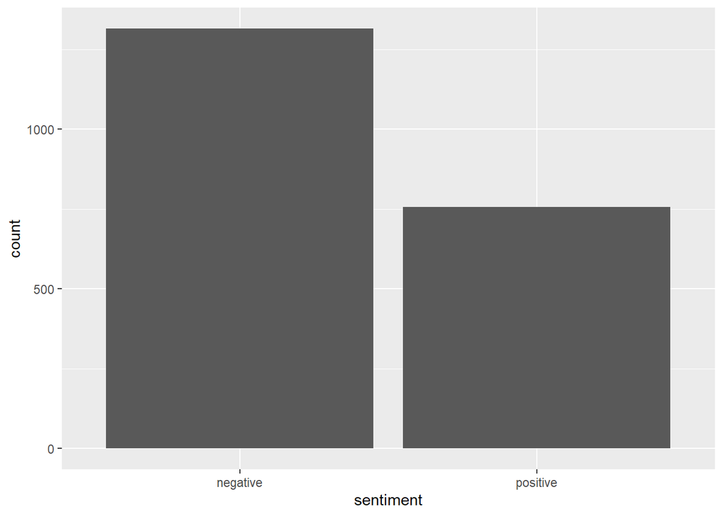

This is reflected when measuring the positivity of the individual books too. The British Navy in Battle contains primarily negative language. The British Navy Book similarly contains a high number of negative words though more positive than The British Navy in Battle. Flag and Fleet has the highest number of positive words though these are still overtaken by a largely negative text.

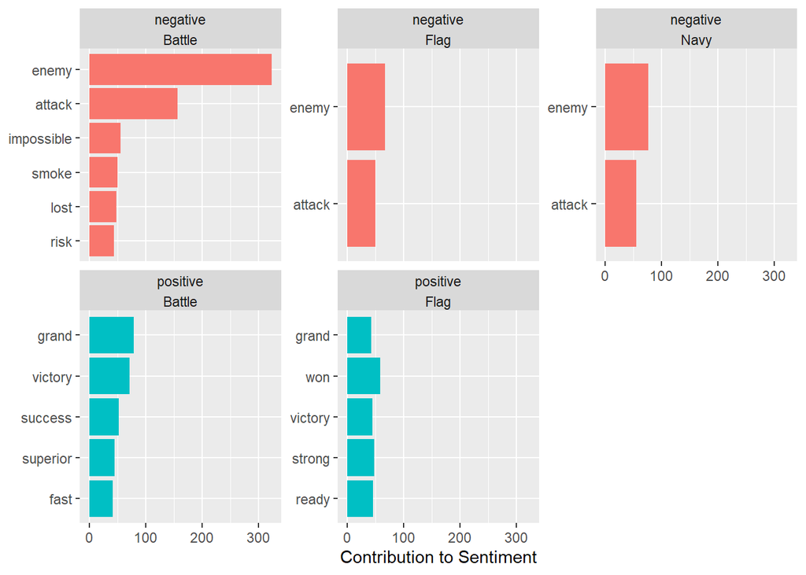

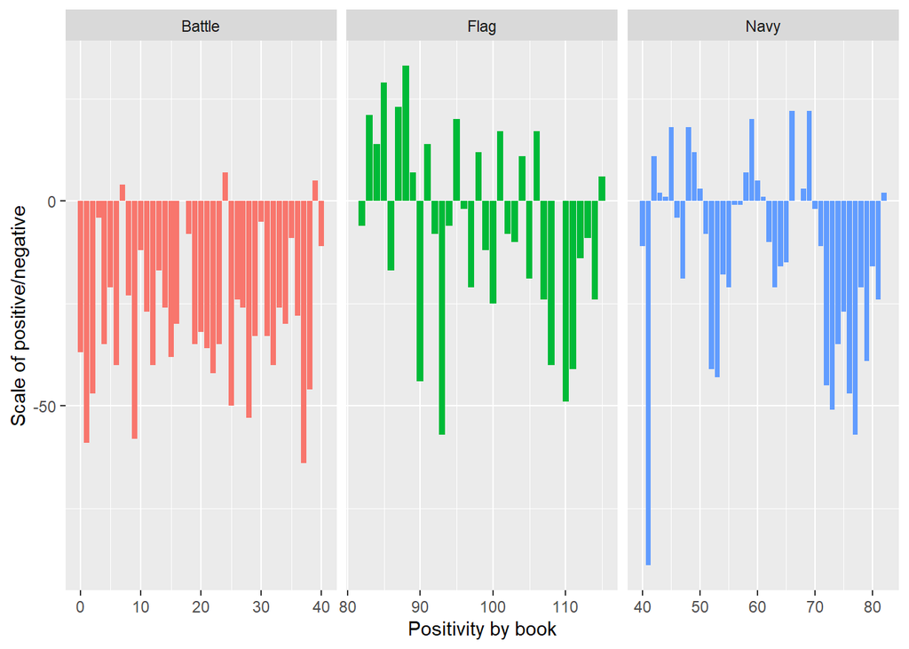

#### Sentiment Context

It is important to consider the context of a word when looking at the positivity value and when negation words are added it can be seen that a number of words have been wrongly assessed as negative so it may be that the corpus is not as negative as it initially appears; however, the wrongly assessed positive words may negate some of this effect.

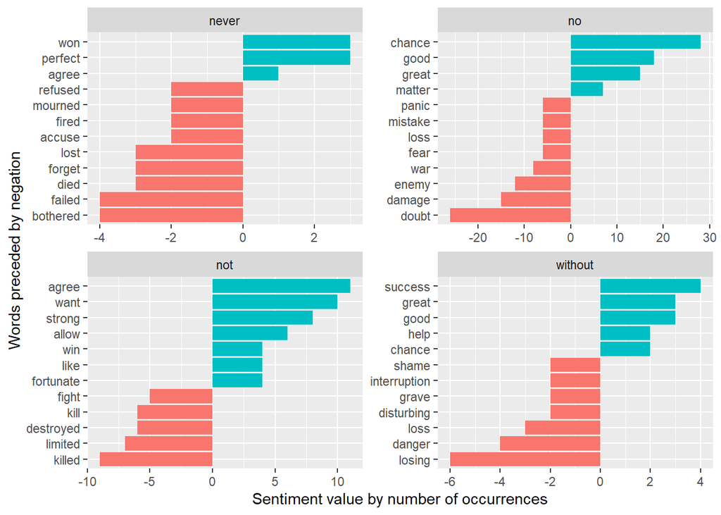